# Lab6: Klasyfikacja

Michał Ciach, Anna Macioszek

March 29, 2020

**Zadanie 1.** Przeskaluj wszystkie kolumny predyktorów z danych `wine`. Możesz w tym celu wykorzystać albo `apply()`, albo funkcję `scale()`. Następnie zrzutuj zmienną `Quality` na typ `factor` za pomocą funkcji `as.factor()` w następujący sposób: `wine$Quality <- as.factor(wine$Quality)`.

```r
wine<-read.csv("wine.csv",sep="\t")
wine[,2:ncol(wine)] <- apply(wine[,-1],MARGIN = 2,function (x) (x-mean(x))/sd(x))
wine$Quality<-as.factor(wine$Quality)
indeksy_testowe <- sample(1:nrow(wine), 480, replace=F)
zbior_testowy <- wine[indeksy_testowe, ]
zbior_treningowy <- wine[-indeksy_testowe, ]
```

### Klasyfikator kNN

**Zadanie 3.** Wykorzystując funkcję `sapply()` i bibliotekę `ggplot2`, przedstaw na wykresie punktowym zależność accuracy od wartości parametru k dla k od 1 do 15. Wykorzystaj w tym celu zbiór testowy i treningowy stworzony w powyższym przykładzie.  
*Wskazówka:* Postaraj się, aby kod służący do otrzymania wektora zawierającego *accuracy* dla różnych wartości $k$ zajął jedynie jedną linijkę.

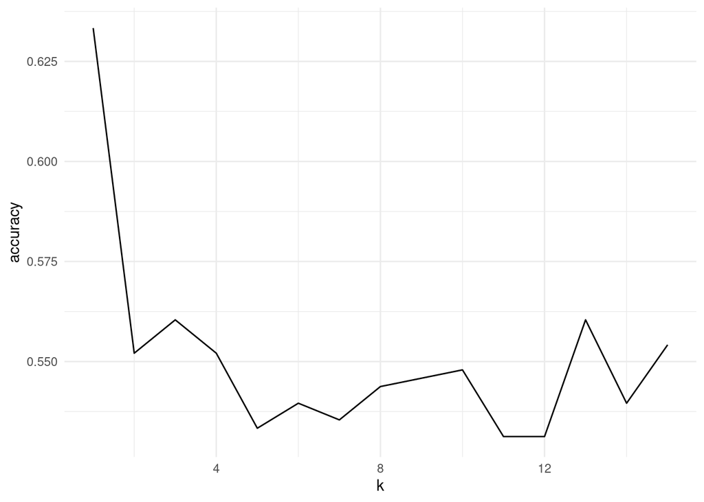

```r
acc<-function(x)
{
  wynik <- knn(zbior_treningowy[,-1], zbior_testowy[,-1], zbior_treningowy[,1], k=x)
  mean(wynik==zbior_testowy[,1])
}
x=1:15
y<-sapply(x,acc)
d<-data.frame("accuracy"=y,"k"=x)
ggplot(d,aes(y=accuracy,x=k))+geom_line()+theme_minimal()
```

### Problem z accuracy

**Zadanie 5.** Utwórz macierz konfuzji dla wyników klasyfikatora kNN na zbiorze testowym z danych `wine`. Skorzystaj z funkcji `table`. Następnie oblicz *precision* oraz *recall* dla każdej klasy. Porównaj wyniki dla 3 wybranych wartości parametru $k$. Na podstawie otrzymanych wyników spróbuj oszacować odpowiedzi na następujące pytania:

- Jeśli klasyfikator twierdzi, że wino ma jakość 7, to jakie jest prawdopodobieństwo, że wino rzeczywiście ma taką jakość?
- Jeśli wino ma jakość 5, to jakie jest prawdopodobieństwo, że klasyfikator zaklasyfikuje je poprawnie?
- Czy klasyfikator lepiej klasyfikuje wina o rzadkich, czy o powszechnych jakościach? Która jakość wina jest poprawnie klasyfikowana najczęściej? Która klasa zwrócona przez klasyfikator jest najbardziej wiarygodna?
- Jaka jest szansa, że w rzeczywistości wino jest lepsze, niż twierdzi klasyfikator? A jaka, że gorsze?

*Wskazówka*. Do obliczenia *precision* oraz *recall* przydadzą się funkcje `diag()`, `rowSums()` oraz `colSums()`. Na przykład, mając macierz konfuzji w zmiennej `C`, do obliczenia *precision* dla każdej klasy wystarczy napisać `diag(C)/colSums(C)`.